# Part II - ( Prosper Loan Data Exploration )

## by (Abdurrahman Muhammad Tukur)

## Investigation Overview

In this investigation, I wanted to look at the attributes of loans that could be used to predict their borrower APR. The main focus was on the Borrowers Apr, EmploymentStatus, Borrower's Prosper rating, LoanTerm, LoanOriginalAmount, StatedMonthly Income.

## Dataset Overview

> > the dataset contains 113,937 rows and 81 columns that depict issued loan, including loan amount, borrower rate (or interest rate), current loan status, borrower income etc. this data will be analyzed visually to generate insight

## Prosper Score Distribution

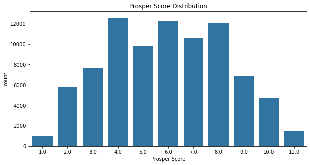

## Borrower State Distribution

California, Texas and New York has the three biggest amount of loan.

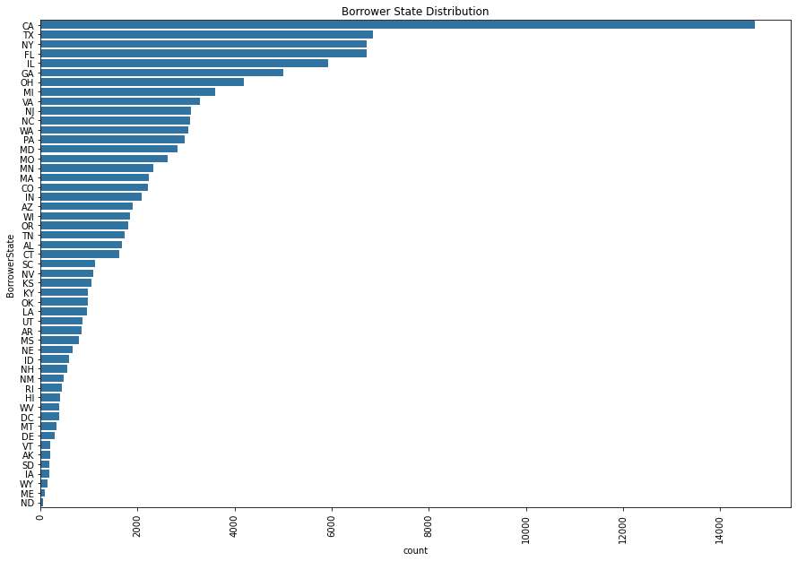

## Borrower Rate and Loan Term split by ProsperRating(Alpha)

usually short term loans would have higher rate and this goes for even creating an amortization table as well because with long rate the interest is compounded which in turn leads to a huge amount exponentially but wouldnt necessarily hurt so much to most people since its a very long time to pay up, there is usally small range of values spanned over a long time, that is when the loan term is long. but in this case i am seeing a lower rate for the short Term.

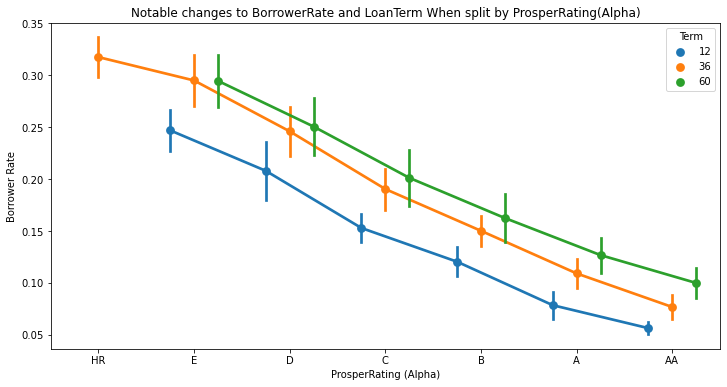

## BorrowerApr vs Loan Status

[figure not shown]

# LenderYield vs Borrower APR vs ProsperRating

Here it is very clear that the plot depicts a positive relationship between the 2 variables BorrowerApr and LenderYield, this correlation shows that when the borrowers of the loan pays, the lenderyield increases but the higher the prosper score the lower the borrowerapr and lenderyield.

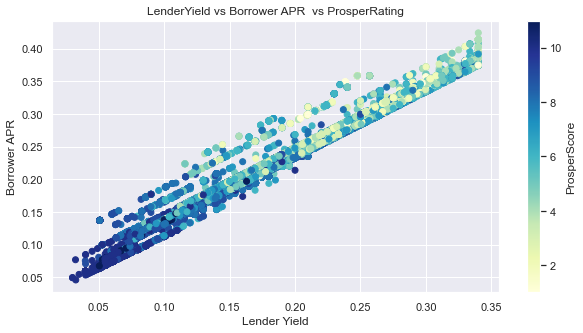